# Final Project

Kasper Noe Rasmussen and Filip B. Rasmussen

2025-05-07

We begin with loading the R-packages

Here we load our libraries

```r
library(tidyverse)
```

We then load in the csv file with our data that we created in excel and give it the name Unemployment

```r
Unemployment <- read_csv("~/Skole/Digitale arkiver og Medier/Dokumenter/RStudio/Final Projekt/Data/Arbejdsløshed 1900-1950 - Ark1 (3).csv")
```

We want to create a graph that shows us the average unemployed people from 1902 to 1950 because 1900 to 1901 has no data

We do this by creating a new value that we call selected_datall

```r
#We want our data from the 14 row and then columns from 4:52
selected_dataall <- Unemployment[14, 4:52]

# We here ensure that it is numeric
selected_dataall <- as.numeric(selected_dataall)

# We want to make sure we have 49 values
print(length(selected_dataall))
```

```
## [1] 49
```

```r
# We then make a corresponding year range to match the 49 years
year_range <- 1902:1950
print(length(year_range))
```

```
## [1] 49
```

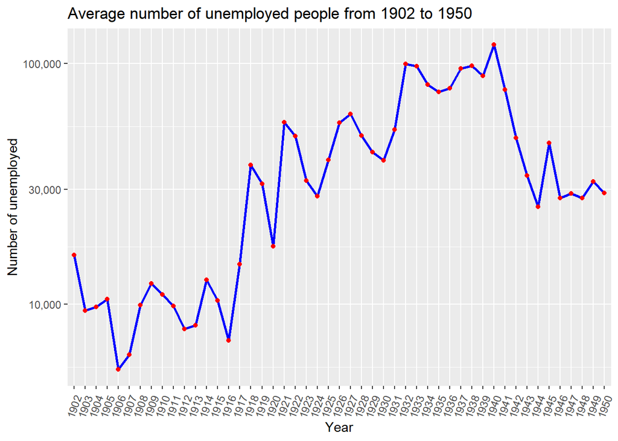

```r
# We now create a data frame with the year range and the selecteddata
dfall <- data.frame(
  Aarall = as.character(year_range),
  Værdiall = selected_dataall)

# Plotting the graph
ggplot(dfall, aes(x = Aarall, y = Værdiall)) +
  geom_line(linewidth = 1, color = "blue", aes(group = 1)) +
  geom_point(color = "red") +
  scale_y_log10(labels = scales::comma) +
  labs(title = "Average number of unemployed people from 1902 to 1950", x = "Year", y = "Number of unemployed") +
  theme(
    axis.text.x = element_text(angle = 70, hjust = 1.1)
  )
```

We want to create some graph that only show us some specific years the first we will do is from 1914 to 1918

```r
# The data we need is from column 16:20 and from row 14
selected_data <- Unemployment[14, 16:20]

# Check selected data
selected_data
```

```
## # A tibble: 1 × 5
##   `1914` `1915` `1916` `1917` `1918`
##    <dbl>  <dbl>  <dbl>  <dbl>  <dbl>
## 1  12663  10352   7076  14651  37877
```

```r
# We make sure our data is numeric
selected_data <- as.numeric(selected_data)
```

The next step is to create the graph

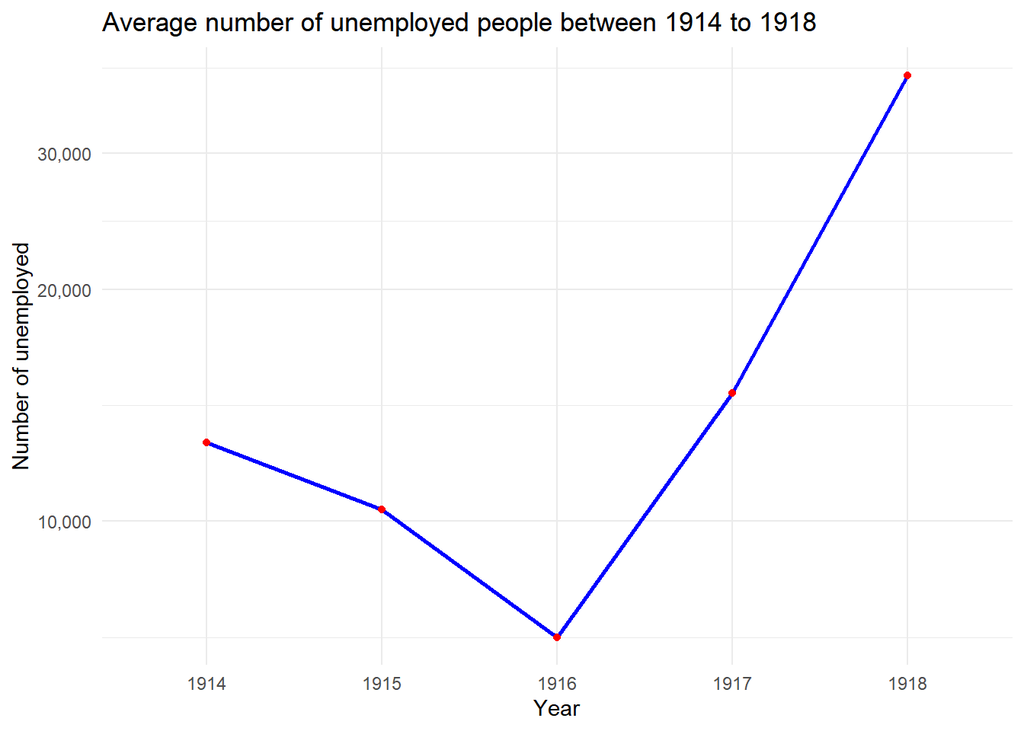

```r
# Here we will create a data frame with the selected_data as the y-axis and the years we want as the x-axis
df <- data.frame(
  Aar = c("1914", "1915", "1916", "1917", "1918"),
  Værdi = as.vector(selected_data))


# Plotting the graph
ggplot(df, aes(x = Aar, y = Værdi)) +
  geom_line(linewidth = 1, color = "blue", aes(group = 1,)) +
  geom_point(color = "red") +
  scale_y_log10(labels = scales::comma)+
  labs(title = "Average number of unemployed people between 1914 to 1918", x = "Year", y = "Number of unemployed") +
  theme_minimal()
```

We will do the same for the years of 1939 to 1945 or ww2

```r
# We want the data from row 14 and column 41 to 47
selected_data2 <- Unemployment[14, 41:47]

# Check the selected data
selected_data2
```

```
## # A tibble: 1 × 7
##   `1939` `1940` `1941` `1942` `1943` `1944` `1945`
##    <dbl>  <dbl>  <dbl>  <dbl>  <dbl>  <dbl>  <dbl>
## 1  88924 119593  77944  48968  34272  25412  46661
```

```r
# We make sure it is numeric
selected_data2 <- as.numeric(selected_data2)
```

We then again have our selected data the on to create the graph

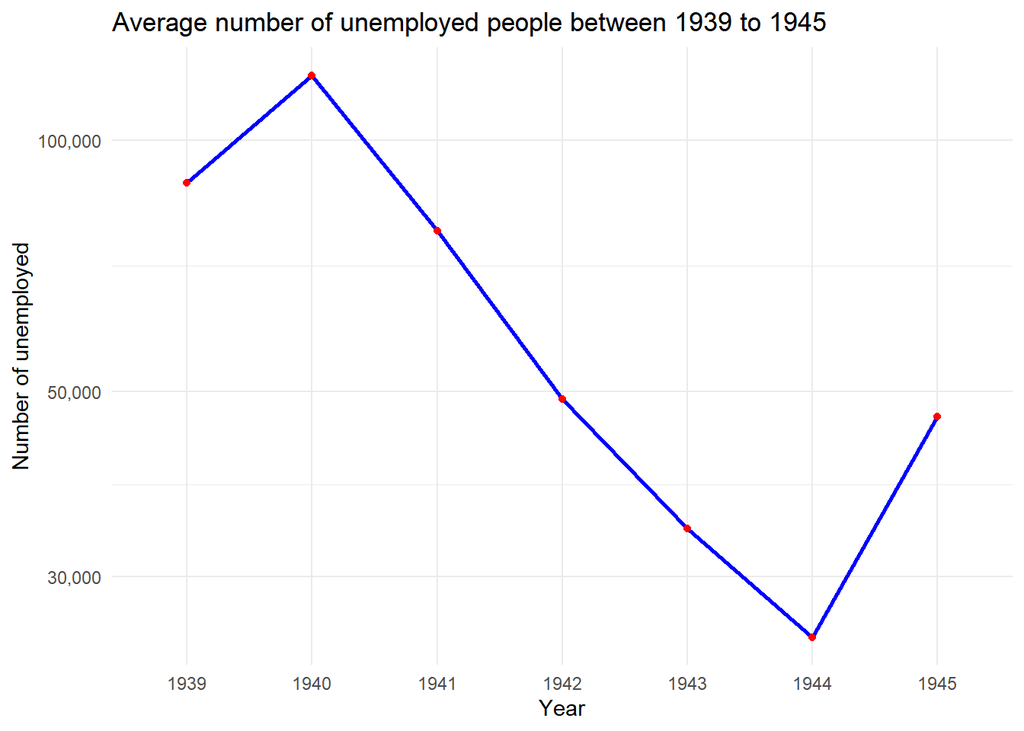

```r
# We first create our data frame for this graph
df2 <- data.frame(
  Aar2 = c("1939", "1940", "1941", "1942", "1943", "1944", "1945"),
  Værdi2 = as.vector(selected_data2)
)

# Plotting the graph
ggplot(df2, aes(x = Aar2, y = Værdi2)) +
  geom_line(linewidth = 1, color = "blue", aes(group = 1,)) +
  geom_point(color = "red") +
  scale_y_log10(labels = scales::comma)+
  labs(title = "Average number of unemployed people between 1939 to 1945", x = "Year", y = "Number of unemployed") +
  theme_minimal()
```

The last of this type of graph will be the years from 1928 to 1934

```r
# The data we want is again from row 14 and column 30 to 36
selected_data3 <- Unemployment[14, 30:36]

# We check the selected data
selected_data3
```

```
## # A tibble: 1 × 7
##   `1928` `1929` `1930` `1931` `1932` `1933` `1934`
##    <dbl>  <dbl>  <dbl>  <dbl>  <dbl>  <dbl>  <dbl>
## 1  50226  42817  39631  53019  99508  97448  81648
```

```r
# We then again make sure it is numeric
selected_data3 <- as.numeric(selected_data3)
```

We can now make our 3rd graph

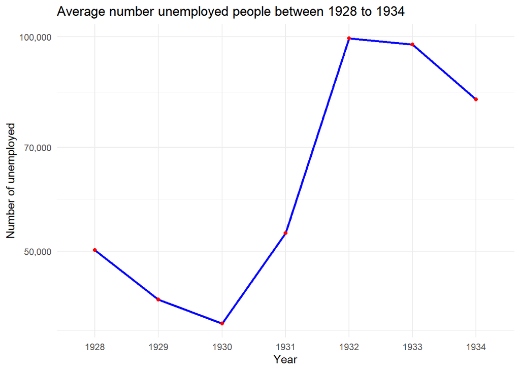

```r
# We create the data frame
df3 <- data.frame(
  Aar3 = c("1928", "1929", "1930", "1931", "1932", "1933", "1934"),
  Værdi3 = as.vector(selected_data3)
)

# Plot the graph
ggplot(df3, aes(x = Aar3, y = Værdi3)) +
  geom_line(linewidth = 1, color = "blue", aes(group = 1,)) +
  geom_point(color = "red") +
  scale_y_log10(labels = scales::comma)+
  labs(title = "Average number unemployed people between 1928 to 1934", x = "Year", y = "Number of unemployed") +
  theme_minimal()
```

We then want to create graph that show us the number of unemployed people over the course of a single year

```r
# We start with creating a data frame with month of the year we want in this case 1902 (our first year)
# We also manually take the values from the datasheet and put it in
data02 <- data.frame(
  date1 = as.Date(c(
    "1902-01-01", "1902-02-01", "1902-03-01", "1902-04-01", "1902-05-01",
    "1902-06-01", "1902-07-01", "1902-08-01", "1902-09-01", "1902-10-01",
    "1902-11-01", "1902-12-01"
  )),
  values1 = c(21857, 21943, 18720, 13515, 15347, 15650, 14095, 12990,
             11580, 12438, 14180, 20155))



# We then check the structure of the data
str(data02)
```

```
## 'data.frame':    12 obs. of  2 variables:
##  $ date1  : Date, format: "1902-01-01" "1902-02-01" ...
##  $ values1: num  21857 21943 18720 13515 15347 ...
```

We can now plot the graph

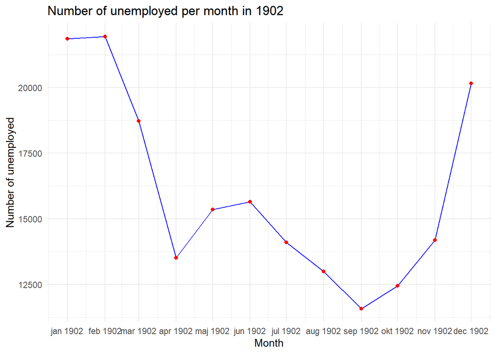

```r
# Plotting the graph
ggplot(data02, aes(x = date1, y = values1)) +
  geom_line(color = "blue") +
  geom_point(color = "red") +
  scale_x_date(date_labels = "%b %Y", date_breaks = "1 month") +
  labs(x = "Month", y = "Number of unemployed", title = "Number of unemployed per month in 1902") +
  theme(axis.text.x = element_text(angle = 45, hjust = 1))+
  theme_minimal()
```

We continue on to the year 1916 during ww1

```r
# We again start by creating a data frame with the months and manually putting in the data
data16 <- data.frame(
  date2 = as.Date(c(
    "1916-01-01", "1916-02-01", "1916-03-01", "1916-04-01", "1916-05-01",
    "1916-06-01", "1916-07-01", "1916-08-01", "1916-09-01", "1916-10-01",
    "1916-11-01", "1916-12-01"
  )),
  values2 = c(15492, 17314, 12654, 6627, 3896, 2880, 2950, 3279,
             2879, 3034, 4858, 9049))


# We check the data
str(data16)
```

```
## 'data.frame':    12 obs. of  2 variables:
##  $ date2  : Date, format: "1916-01-01" "1916-02-01" ...
##  $ values2: num  15492 17314 12654 6627 3896 ...
```

We then create the graph

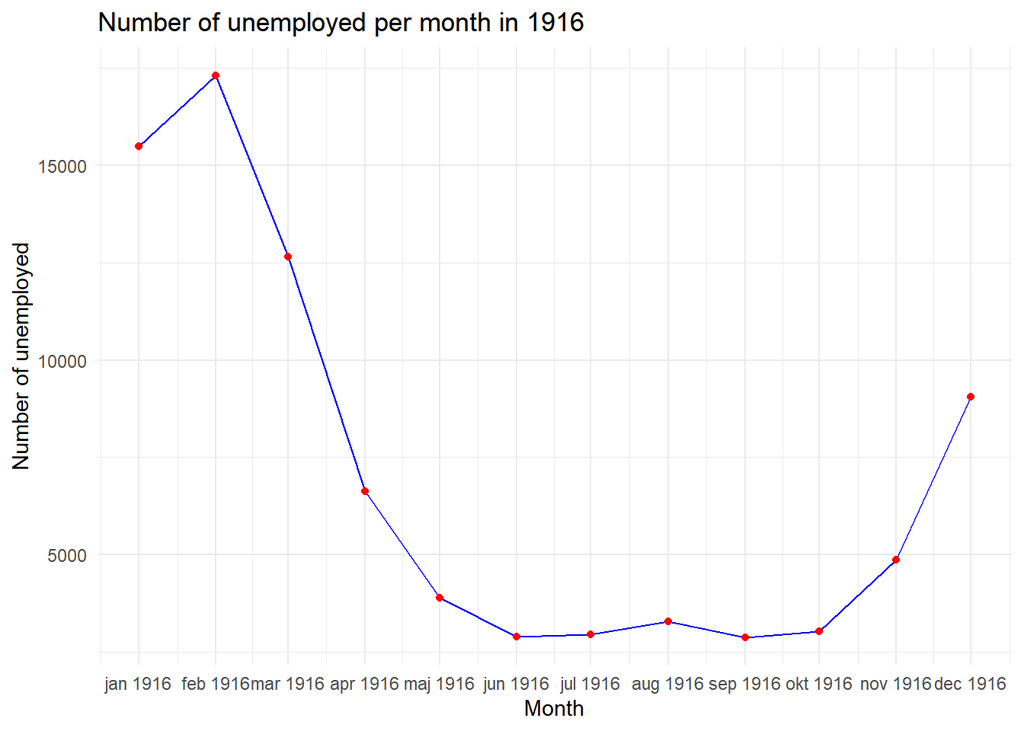

```r
ggplot(data16, aes(x = date2, y = values2)) +
  geom_line(color = "blue") +
  geom_point(color = "red") +
  scale_x_date(date_labels = "%b %Y", date_breaks = "1 month") +
  labs(x = "Month", y = "Number of unemployed", title = "Number of unemployed per month in 1916") +
  theme(axis.text.x = element_text(angle = 45, hjust = 1))+
  theme_minimal()
```

We then move on to year 1925

```r
# We create the data frame
data25 <- data.frame(
  date3 = as.Date(c(
    "1925-01-01", "1925-02-01", "1925-03-01", "1925-04-01", "1925-05-01",
    "1925-06-01", "1925-07-01", "1925-08-01", "1925-09-01", "1925-10-01",
    "1925-11-01", "1925-12-01"
  )),
  values3 = c(44643, 44468, 40055, 35646, 31807, 24135, 22393, 26348,
              28509, 36526, 55797, 85944)
)

# Check the data
str(data25)
```

```
## 'data.frame':    12 obs. of  2 variables:
##  $ date3  : Date, format: "1925-01-01" "1925-02-01" ...
##  $ values3: num  44643 44468 40055 35646 31807 ...
```

We create our graph with our new data frame

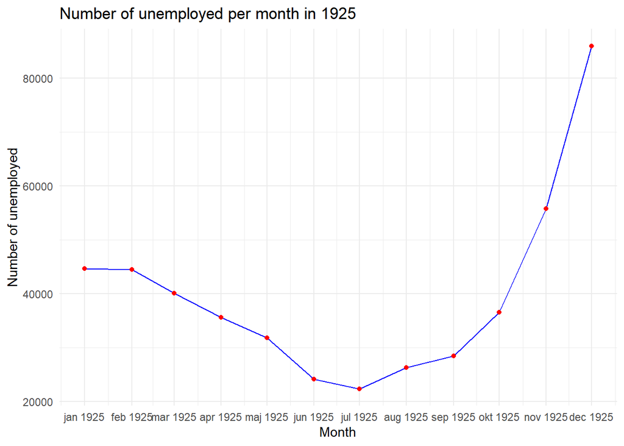

```r
ggplot(data25, aes(x = date3, y = values3)) +
  geom_line(color = "blue") +
  geom_point(color = "red") +
  scale_x_date(date_labels = "%b %Y", date_breaks = "1 month") +
  labs(x = "Month", y = "Number of unemployed", title = "Number of unemployed per month in 1925") +
  theme(axis.text.x = element_text(angle = 45, hjust = 1))+
  theme_minimal()
```

Now we are on to year 1933

```r
# We create the data frame
data33 <- data.frame(
  date4 = as.Date(c(
    "1933-01-01", "1933-02-01", "1933-03-01", "1933-04-01", "1933-05-01",
    "1933-06-01", "1933-07-01", "1933-08-01", "1933-09-01", "1933-10-01",
    "1933-11-01", "1933-12-01"
  )),
  values4 = c(141354, 140134, 116762, 95692, 81535, 73542, 73338, 72559,
             72017, 80565, 89948, 131930))


# Check the data
str(data33)
```

```
## 'data.frame':    12 obs. of  2 variables:
##  $ date4  : Date, format: "1933-01-01" "1933-02-01" ...
##  $ values4: num  141354 140134 116762 95692 81535 ...
```

Time to create the graph

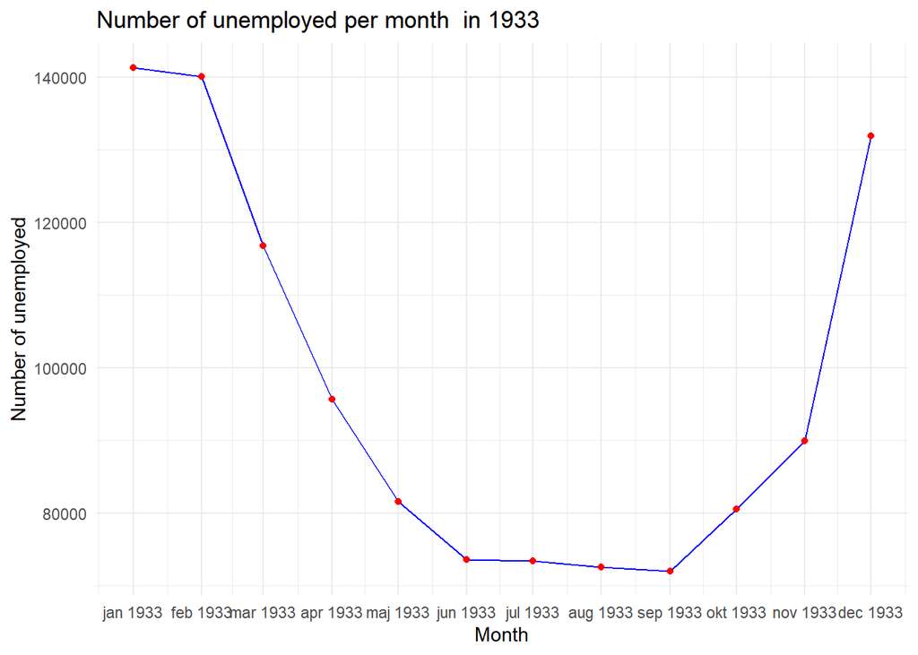

```r
ggplot(data33, aes(x = date4, y = values4)) +
  geom_line(color = "blue") +
  geom_point(color = "red") +
  scale_x_date(date_labels = "%b %Y", date_breaks = "1 month") +
  labs(x = "Month", y = "Number of unemployed", title = "Number of unemployed per month  in 1933") +
  theme(axis.text.x = element_text(angle = 45, hjust = 1))+
  theme_minimal()
```

We have the graph that show us the year 1940

```r
data40 <- data.frame(
  date5 = as.Date(c(
    "1940-01-01", "1940-02-01", "1940-03-01", "1940-04-01", "1940-05-01",
    "1940-06-01", "1940-07-01", "1940-08-01", "1940-09-01", "1940-10-01",
    "1940-11-01", "1940-12-01"
  )),
  values5 = c(149179, 163871, 152495, 129972, 101422, 84636, 80928, 89673,
             89936, 96332, 117262, 179410)
)

str(data40)
```

```
## 'data.frame':    12 obs. of  2 variables:
##  $ date5  : Date, format: "1940-01-01" "1940-02-01" ...
##  $ values5: num  149179 163871 152495 129972 101422 ...
```

We create the graph

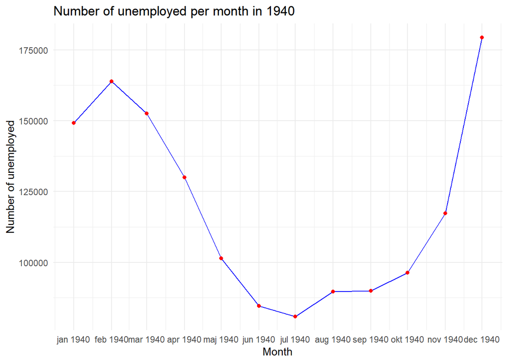

```r
ggplot(data40, aes(x = date5, y = values5)) +
  geom_line(color = "blue") +
  geom_point(color = "red") +
  scale_x_date(date_labels = "%b %Y", date_breaks = "1 month") +
  labs(x = "Month", y = "Number of unemployed", title = "Number of unemployed per month in 1940") +
  theme(axis.text.x = element_text(angle = 45, hjust = 1))+
  theme_minimal()
```

At last we create for the year 1947

```r
# We create our last data frame
data47 <- data.frame(
  date6 = as.Date(c(
    "1947-01-01", "1947-02-01", "1947-03-01", "1947-04-01", "1947-05-01",
    "1947-06-01", "1947-07-01", "1947-08-01", "1947-09-01", "1947-10-01",
    "1947-11-01", "1947-12-01"
  )),
  values6 = c(71966, 89910, 70352, 17913, 6391, 3309, 3275, 4076,
             7714, 12282, 20794, 37569))


# Check the data for the last time
str(data47)
```

```
## 'data.frame':    12 obs. of  2 variables:
##  $ date6  : Date, format: "1947-01-01" "1947-02-01" ...
##  $ values6: num  71966 89910 70352 17913 6391 ...
```

We then create the last graph

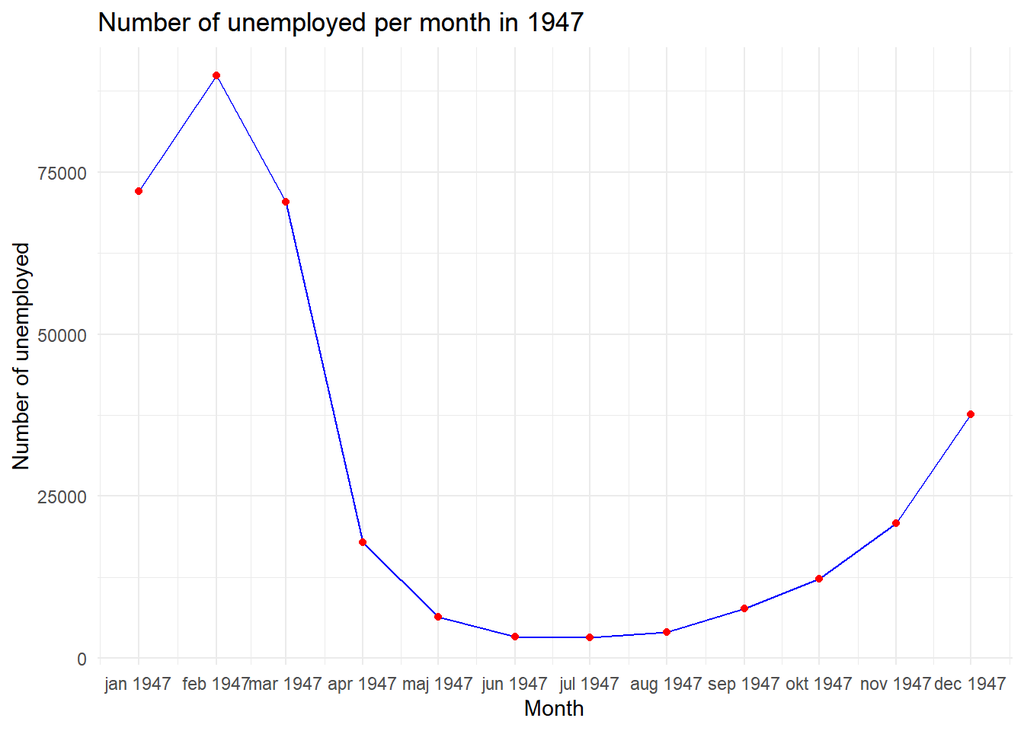

```r
ggplot(data47, aes(x = date6, y = values6)) +
  geom_line(color = "blue") +
  geom_point(color = "red") +
  scale_x_date(date_labels = "%b %Y", date_breaks = "1 month") +
  labs(x = "Month", y = "Number of unemployed", title = "Number of unemployed per month in 1947") +
  theme(axis.text.x = element_text(angle = 45, hjust = 1))+
  theme_minimal()
```

We will now create a graph showing percent over the period 1910 to 1950

```r
#We want our data from the 16 row and then columns from 12:52
selected_dataallp <- Unemployment[16, 12:52]

# We here ensure that it is numeric
selected_dataallp <- as.numeric(selected_dataallp)

# We want to make sure we have 41 values
print(length(selected_dataallp))
```

```
## [1] 41
```

```r
# We then make a corresponding year range to match the 41 years
year_rangep <- 1910:1950
print(length(year_rangep))
```

```
## [1] 41
```

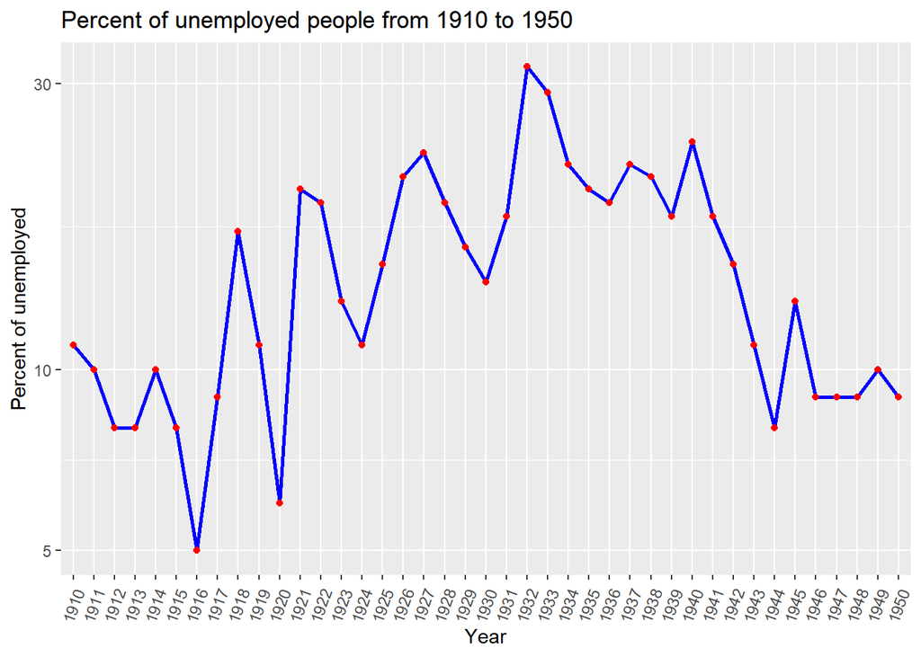

```r
# We now create a data frame with the year range and the selecteddata
dfallp <- data.frame(
  Aarallp = as.character(year_rangep),
  Værdiallp = selected_dataallp)

# Plotting the graph
ggplot(dfallp, aes(x = Aarallp, y = Værdiallp)) +
  geom_line(linewidth = 1, color = "blue", aes(group = 1)) +
  geom_point(color = "red") +
  scale_y_log10(labels = scales::comma) +
  labs(title = "Percent of unemployed people from 1910 to 1950", x = "Year", y = "Percent of unemployed") +
  theme(
    axis.text.x = element_text(angle = 70, hjust = 1.1)
  )
```

We then want to create graph with percent over the years 1914 to 1918, 1928 to 1934 and 1939 to 1945

We will start with 1914 to 1918

```r
# The data we need is from column 16:20 and from row 16
selected_dataww1 <- Unemployment[16, 16:20]

# Check selected data
selected_dataww1
```

```
## # A tibble: 1 × 5
##   `1914` `1915` `1916` `1917` `1918`
##    <dbl>  <dbl>  <dbl>  <dbl>  <dbl>
## 1     10      8      5      9     17
```

```r
# We make sure our data is numeric
selected_dataww1 <- as.numeric(selected_dataww1)
```

The next step is to create the graph

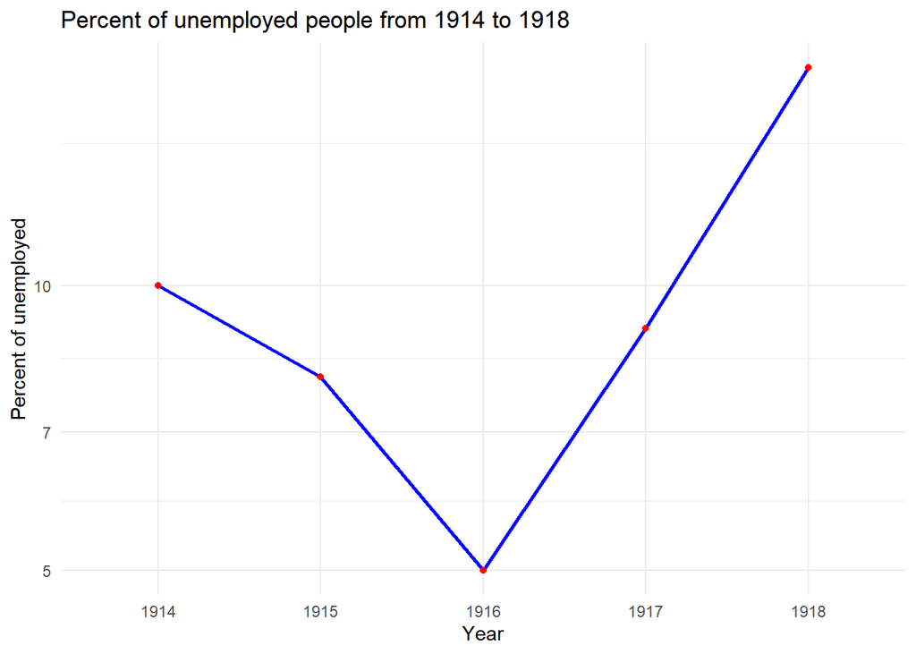

```r
# Here we will create a data frame with the selected_data as the y-axis and the years we want as the x-axis
dfww1 <- data.frame(
  Aarww1 = c("1914", "1915", "1916", "1917", "1918"),
  Værdiww1 = as.vector(selected_dataww1))


# Plotting the graph
ggplot(dfww1, aes(x = Aarww1, y = Værdiww1)) +
  geom_line(linewidth = 1, color = "blue", aes(group = 1,)) +
  geom_point(color = "red") +
  scale_y_log10(labels = scales::comma)+
  labs(title = "Percent of unemployed people from 1914 to 1918", x = "Year", y = "Percent of unemployed") +
  theme_minimal()
```

We then move on to 1928 to 1934

```r
# The data we want is again from row 16 and column 30 to 36
selected_datad <- Unemployment[16, 30:36]

# We check the selected data
selected_datad
```

```
## # A tibble: 1 × 7
##   `1928` `1929` `1930` `1931` `1932` `1933` `1934`
##    <dbl>  <dbl>  <dbl>  <dbl>  <dbl>  <dbl>  <dbl>
## 1     19     16     14     18     32     29     22
```

```r
# We then again make sure it is numeric
selected_datad <- as.numeric(selected_datad)
```

We can now make the graph

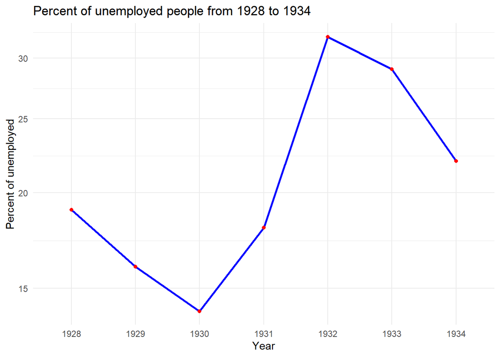

```r
# We create the data frame
dfd <- data.frame(
  Aard = c("1928", "1929", "1930", "1931", "1932", "1933", "1934"),
  Værdid = as.vector(selected_datad)
)

# Plot the graph
ggplot(dfd, aes(x = Aard, y = Værdid)) +
  geom_line(linewidth = 1, color = "blue", aes(group = 1,)) +
  geom_point(color = "red") +
  scale_y_log10(labels = scales::comma)+
  labs(title = "Percent of unemployed people from 1928 to 1934", x = "Year", y = "Percent of unemployed") +
  theme_minimal()
```

We then move on to the last percent graph 1939 to 1945

```r
# We want the data from row 16 and column 41 to 47
selected_dataww2 <- Unemployment[16, 41:47]

# Check the selected data
selected_dataww2
```

```
## # A tibble: 1 × 7
##   `1939` `1940` `1941` `1942` `1943` `1944` `1945`
##    <dbl>  <dbl>  <dbl>  <dbl>  <dbl>  <dbl>  <dbl>
## 1     18     24     18     15     11      8     13
```

```r
# We make sure it is numeric
selected_dataww2 <- as.numeric(selected_dataww2)
```

We can now make the last percent graph

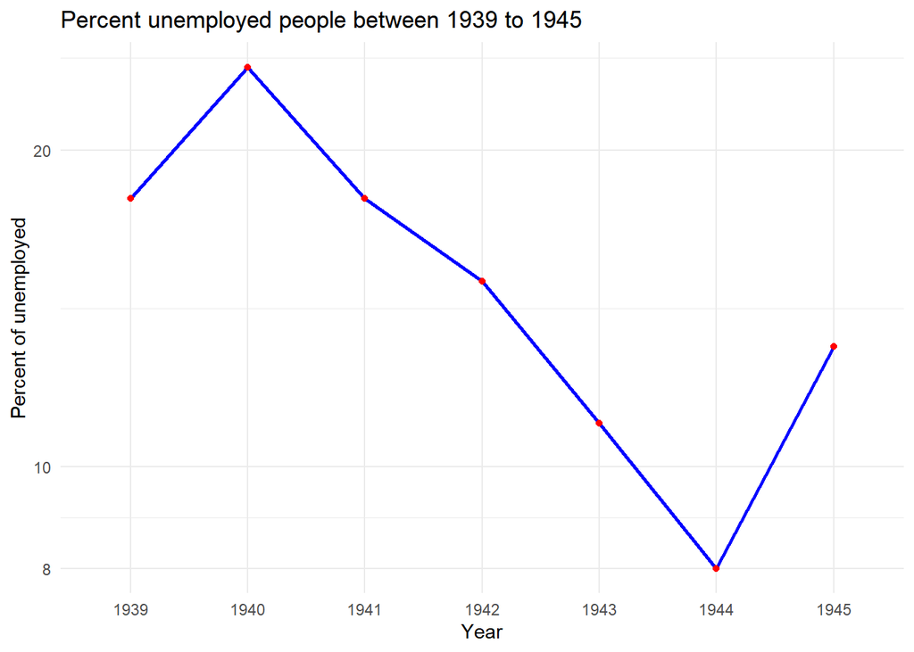

```r
# We first create our data frame for this graph
dfww2 <- data.frame(
  Aarww2 = c("1939", "1940", "1941", "1942", "1943", "1944", "1945"),
  Værdiww2 = as.vector(selected_dataww2)
)

# Plotting the graph
ggplot(dfww2, aes(x = Aarww2, y = Værdiww2)) +
  geom_line(linewidth = 1, color = "blue", aes(group = 1,)) +
  geom_point(color = "red") +
  scale_y_log10(labels = scales::comma)+
  labs(title = "Percent unemployed people between 1939 to 1945", x = "Year", y = "Percent of unemployed") +
  theme_minimal()
```

We have now created 14 graph

The first graph show us the Average number of unemployed people from 1902 to 1950

The following 3 show us the average number of unemployed over the span of 4 to 6 years

The following 6 graph show us the number of unemployed people during each month of a specific year

The last 4 are graph like the first and second row above but with percent instead of the average number